# Finding Driver Mutation (DriverNet)

# I. Introduction to DriverNet

Driver Net package finds functionally important driver mutations in cancer by integrating DNA data and RNA data. It was introduced back in [2012 on Genome Biology](https://genomebiology.biomedcentral.com/articles/10.1186/gb-2012-13-12-r124). The package merges mutational matrix (somatic mutation and CNVs), influence graph, and gene expression information to explore driver mutations. Traditional analytical tools focused on finding the most frequent functional mutations, but on the other hand, DriverNet added gene expression network information to this to select for candidates and test hypothesis by permutation tests. Following is an awesome explanation by Jared Wilber: [The Permutation Test Explained In the Perspective of An Alpaca Shepherd](https://www.jwilber.me/permutationtest/). There’s control and there’s experimental. Distribution and the statistics are measured in each group. And then samples in each group are randomly permuted and the statistic measured again. With multiple permutation events, one can draw out how likely the original condition arises from random event. If the p-value is small enough, we can tell whether something really has significant statistical difference or not.

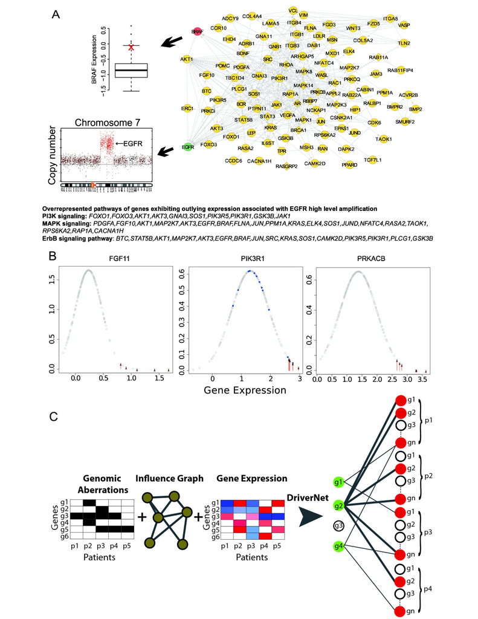

Bashashati, et al., Genome Biology, 2012

> As one can see in the picture, especially in Figure C, genomic aberration states + gene expression data + influence together capture biological pathway information, which results in the bipartile graph shown on right. Green nodes in the left partition indicate genomic mutationst, and red nodes on the right correspond to outlying gene expression value in each patient. Each patient is represented by an edge (connection) if the three following conditions are met: i) gene *$g_i$* is mutated in patient *p* of the population (green nodes); ii) gene *$g_j$* indicates outlying expression in patient *p* (red nodes on the right); iii) *$g_i$* and *$g_j$* are known to interact according to pathway or gene set databases (represented by an “influence graph”, after [Vandin, et al. JofCompBio, 2011](https://pubmed.ncbi.nlm.nih.gov/21385051/)) The genes with the highest number of outlying expression events (g2, in the above picture) are nominated as putative drivers.

# II. Install R DriverNet Package and Load Data

```r
if (!requireNamespace("BiocManager", quietly = TRUE))
  install.packages("BiocManager")
  BiocManager::install("DriverNet")
```

```r
library(DriverNet)
data(samplePatientMutationMatrix)
data(samplePatientOutlierMatrix)
data(sampleInfluenceGraph)
data(sampleGeneNames)
```

```r
sPMM <- samplePatientMutationMatrix
sPOM <- samplePatientOutlierMatrix
sIG <- sampleInfluenceGraph
sGN <- sampleGeneNames
```

The example data contains 120 (GBM) patient’s and 1255 gene information from TCGA. Let’s have a peek at the data.

1. samplePtientMutationMatrix(sPMM): 120 patients’ somatic mutation information in binary format. (mutation (+) = 1, mutation (-) = 0)

```r
head(sPMM, 10)[,1:10]
```

```
##                 ABCC4 AOC3 APBB1IP APC ATM ATP6V1E1 ATR BRCA2 BTK CAST
## TCGA-02-0083-01     1    0       0   0   0        1   0     0   0    0
## TCGA-02-0037-01     1    0       0   0   0        0   0     0   0    0
## TCGA-06-0210-01     0    0       0   0   0        0   0     0   0    0
## TCGA-02-0025-01     0    0       0   0   0        0   0     0   0    0
## TCGA-02-0015-01     0    0       0   1   0        0   0     0   0    1
## TCGA-02-0064-01     0    0       0   0   0        0   0     0   0    0
## TCGA-02-0014-01     0    1       0   0   0        0   0     1   0    0
## TCGA-06-0209-01     0    1       0   0   0        0   0     0   0    0
## TCGA-02-0114-01     0    0       0   0   1        0   0     0   0    0
## TCGA-02-0028-01     0    0       0   0   0        0   0     0   0    0
```

2. samplePatientOutlierMatrix(sPOM): This matrix shows whether 120 patients’ (n=120) gene expression (n=1255) have outliers or not.

```r
head(sPOM, 10)[,1:10]
```

```
##                 ABCC4  AOC3 APBB1IP   APC   ATM ATP6V1E1   ATR BRCA2   BTK
## TCGA-02-0083-01 FALSE FALSE   FALSE FALSE FALSE    FALSE FALSE FALSE FALSE
## TCGA-02-0037-01 FALSE FALSE   FALSE FALSE FALSE    FALSE FALSE FALSE FALSE
## TCGA-06-0210-01 FALSE FALSE   FALSE FALSE FALSE    FALSE FALSE FALSE FALSE
## TCGA-02-0025-01 FALSE FALSE   FALSE  TRUE FALSE    FALSE FALSE FALSE FALSE
## TCGA-02-0015-01 FALSE FALSE   FALSE FALSE FALSE    FALSE FALSE FALSE FALSE
## TCGA-02-0064-01 FALSE FALSE   FALSE FALSE FALSE    FALSE FALSE FALSE FALSE
## TCGA-02-0014-01 FALSE FALSE   FALSE FALSE FALSE    FALSE FALSE  TRUE FALSE
## TCGA-06-0209-01 FALSE FALSE    TRUE FALSE FALSE    FALSE FALSE FALSE FALSE
## TCGA-02-0114-01 FALSE FALSE   FALSE FALSE FALSE    FALSE FALSE  TRUE FALSE
## TCGA-02-0028-01 FALSE FALSE    TRUE FALSE FALSE    FALSE  TRUE FALSE FALSE
##                  CAST
## TCGA-02-0083-01 FALSE
## TCGA-02-0037-01 FALSE
## TCGA-06-0210-01 FALSE
## TCGA-02-0025-01 FALSE
## TCGA-02-0015-01 FALSE
## TCGA-02-0064-01 FALSE
## TCGA-02-0014-01  TRUE
## TCGA-06-0209-01 FALSE
## TCGA-02-0114-01 FALSE
## TCGA-02-0028-01 FALSE
```

3. sampleInfluenceGraph (sIG): Influence graph shows whether two genes participate in a same pathway or not. (Same pathway 1, not 0).

```r
head(sIG, 10)[,1:10]
```

```
##          ABCC4 AOC3 APBB1IP APC ATM ATP6V1E1 ATR BRCA2 BTK CAST
## ABCC4        1    0       0   0   0        0   0     0   0    0
## AOC3         0    1       0   0   0        1   0     0   0    0
## APBB1IP      0    0       1   0   0        0   0     0   0    0
## APC          0    0       0   1   1        0   0     1   1    0
## ATM          0    0       0   1   1        0   1     1   1    0
## ATP6V1E1     0    1       0   0   0        1   0     0   0    0
## ATR          0    0       0   0   1        0   1     1   0    0
## BRCA2        0    0       0   1   1        0   1     1   0    0
## BTK          0    0       0   1   1        0   0     0   1    0
## CAST         0    0       0   0   0        0   0     0   0    1
```

4. sampleGeneNames (sGN): Name list of genes to be tested for permutation test.

```r
head(sampleGeneNames, 10)
```

```
##  [1] OR4F29        OR4F16        AL669831.13-3 FAM87B        SAMD11
##  [6] NOC2L         KLHL17        PLEKHN1       C1orf170      HES4
## 20846 Levels: A1BG A1CF A26C1B A2BP1 A2LD1 A2M A2ML1 A3GALT2 A4GALT A4GNT ... ZZZ3
```

# III. Functionalities of This Package Includes:

## Print driver mutations list from the highest rank to the lowest.

With “greedy” algorithm, determines the driver mutation rank by computing covered event.

The main function to compute drivers:

> `driversList = computeDrivers(samplePatientMutationMatrix,samplePatientOutlierMatrix, sampleInfluenceGraph, outputFolder=NULL, printToConsole=FALSE)`

```r
driversList=computeDrivers(sPMM,sPOM,sIG,outputFolder=NULL, printToConsole=FALSE)
```

```r
drivers(driversList)[1:10]
```

```
##  [1] "EGFR"    "TP53"    "MTAP"    "PTEN"    "PIK3R1"  "CDKN2A"  "CYP27B1"
##  [8] "PIK3CA"  "PDGFRA"  "IDH1"
```

## Random permute the gene labels to compute p-values

Driver mutation gene’s statistical significance is tested by randomized method. Original data is N-th permuted and then compared to the original data to see how much the distributions resemble each other through statistics.

> computeRandomizedResult(patMutMatrix=samplePatient, patOutMatrix=samplePatientOutlierMatrix, influenceGraph=sampleInfluenceGraph, geneNameList= sampleGeneNames, outputFolder=NULL, printToConsole=FALSE, numberOfRandomTests=20, weight=FALSE, purturbGraph=FALSE, purturbData=TRUE)

```r
randomDriversResult = computeRandomizedResult(sPMM, sPOM, sIG, sGN, outputFolder=NULL, printToConsole=FALSE, numberOfRandomTests=20, weight=FALSE, purturbGraph=FALSE, purturbData=TRUE)
```

## Summarize the results

```r
res = resultSummary(driversList, randomDriversResult, sPMM, sIG, outputFolder=NULL, printToConsole=FALSE)
```

```r
head(res)
```

```
##        rank gene     mut  p-value total_events covered_events node_degree
## EGFR   "1"  "EGFR"   "50" "0"     "16695"      "791"          "396"
## TP53   "2"  "TP53"   "38" "0"     "16695"      "659"          "416"
## MTAP   "3"  "MTAP"   "53" "0"     "16695"      "336"          "181"
## PTEN   "4"  "PTEN"   "40" "0"     "16695"      "222"          "328"
## PIK3R1 "5"  "PIK3R1" "11" "0"     "16695"      "208"          "508"
## CDKN2A "6"  "CDKN2A" "55" "0"     "16695"      "150"          "241"
##        no.of.cases
## EGFR   "50"
## TP53   "38"
## MTAP   "47"
## PTEN   "34"
## PIK3R1 "11"
## CDKN2A "30"
##        connected.drivers
## EGFR   "1,2,4,5,6,8,9,13,14,15,16,17,18,19,20,21,23,26,27,28,31,32,33,34,36,38,39,40,44,45,47,48,50,52,55,56,59,60,61,62,63,64,65,67,68,70,72,73,84,86,87,88,89,90,93,95,98,102,103,109,110,121,124,127,130,133,137,138,139,140,141,142,144,146,148,150,153,156,158,164,166,167,169,170,173,175,181,186,1…
## TP53   "1,2,4,5,6,8,9,12,13,14,17,18,19,20,21,23,26,27,28,30,33,34,36,38,39,40,42,43,44,45,47,48,50,51,52,55,56,59,60,63,64,65,67,68,70,72,73,74,86,87,88,89,90,91,95,96,102,105,107,112,121,127,129,130,131,132,135,137,138,139,140,141,142,146,150,153,156,157,158,164,166,167,171,172,173,175,177,181,…
## MTAP   "3,7,10,12,15,18,22,29,32,37,42,53,78,84,96,97,126,143,157,176,180,204,222,224,227"
## PTEN   "1,2,4,5,6,8,9,13,14,15,17,19,20,21,23,26,27,28,32,33,34,36,38,39,40,44,47,50,52,55,56,60,62,63,64,65,68,70,72,73,86,87,88,89,91,93,95,96,102,105,109,121,124,127,130,132,135,137,138,139,140,141,142,150,153,156,158,164,167,169,172,175,181,185,186,191,192,193,196,199,201,202,205,206,208,209,…
## PIK3R1 "1,2,4,5,6,8,9,13,14,15,16,17,18,19,20,21,23,26,27,28,30,32,33,34,36,38,39,40,44,45,47,50,52,54,55,56,59,60,62,63,64,65,68,69,70,71,72,73,74,80,86,87,88,89,91,93,95,96,102,106,109,121,124,127,128,129,130,134,135,136,137,138,139,140,141,142,145,150,153,156,158,164,166,167,169,170,172,173,17…
## CDKN2A "1,2,4,5,6,8,9,13,14,17,19,21,23,27,33,36,38,39,40,44,47,50,51,52,55,56,60,63,65,68,70,72,73,86,87,88,89,91,95,102,105,121,127,130,132,135,137,138,139,140,141,153,156,164,167,172,173,175,177,181,191,193,196,201,202,205,206,208,213,222,231,233"
##        case
## EGFR   "TCGA-02-0083-01,TCGA-02-0064-01,TCGA-06-0209-01,TCGA-06-0169-01,TCGA-02-0043-01,TCGA-06-0219-01,TCGA-06-0185-01,TCGA-08-0353-01,TCGA-08-0390-01,TCGA-02-0021-01,TCGA-08-0246-01,TCGA-02-0007-01,TCGA-02-0089-01,TCGA-06-0148-01,TCGA-06-0157-01,TCGA-06-0127-01,TCGA-08-0349-01,TCGA-08-0380-01,T…
## TP53   "TCGA-02-0083-01,TCGA-02-0037-01,TCGA-02-0025-01,TCGA-02-0114-01,TCGA-06-0184-01,TCGA-02-0075-01,TCGA-02-0084-01,TCGA-02-0055-01,TCGA-08-0353-01,TCGA-02-0026-01,TCGA-02-0089-01,TCGA-02-0046-01,TCGA-02-0003-01,TCGA-08-0389-01,TCGA-06-0190-01,TCGA-12-0618-01,TCGA-08-0245-01,TCGA-02-0048-01,T…
## MTAP   "TCGA-02-0037-01,TCGA-06-0210-01,TCGA-02-0015-01,TCGA-02-0064-01,TCGA-02-0014-01,TCGA-06-0169-01,TCGA-02-0104-01,TCGA-02-0043-01,TCGA-02-0115-01,TCGA-06-0219-01,TCGA-06-0185-01,TCGA-02-0047-01,TCGA-06-0158-01,TCGA-08-0353-01,TCGA-08-0246-01,TCGA-02-0089-01,TCGA-06-0148-01,TCGA-06-0127-01,T…
## PTEN   "TCGA-02-0015-01,TCGA-02-0014-01,TCGA-06-0184-01,TCGA-02-0043-01,TCGA-02-0075-01,TCGA-02-0055-01,TCGA-06-0168-01,TCGA-06-0219-01,TCGA-02-0007-01,TCGA-08-0380-01,TCGA-06-0125-01,TCGA-08-0389-01,TCGA-06-0190-01,TCGA-12-0618-01,TCGA-08-0386-01,TCGA-02-0006-01,TCGA-02-0079-01,TCGA-06-0648-01,T…
## PIK3R1 "TCGA-02-0114-01,TCGA-02-0028-01,TCGA-02-0021-01,TCGA-02-0089-01,TCGA-02-0003-01,TCGA-02-0048-01,TCGA-06-0129-01,TCGA-02-0074-01,TCGA-06-0178-01,TCGA-02-0068-01,TCGA-08-0350-01"
## CDKN2A "TCGA-06-0210-01,TCGA-02-0064-01,TCGA-02-0014-01,TCGA-06-0169-01,TCGA-02-0104-01,TCGA-02-0115-01,TCGA-06-0185-01,TCGA-02-0047-01,TCGA-06-0158-01,TCGA-08-0353-01,TCGA-06-0148-01,TCGA-06-0127-01,TCGA-02-0116-01,TCGA-06-0125-01,TCGA-02-0023-01,TCGA-08-0375-01,TCGA-06-0143-01,TCGA-06-0648-01,T…
```

rank: Ranked order of driver mutations extracted by DriverNet

gene: gene symbols

mut: number of mutations (includes SNV, CNV #)

p-value: (expressed as 0 if <1.0E-3) p-value corrected and obtained from Benjamini-Hochberg procedure[^1]

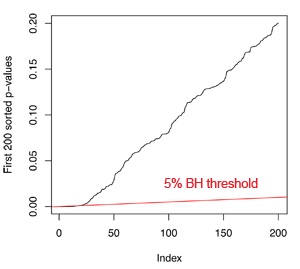

total_events: All edges in the bipartile graph.

covered_events: All edges (events) connected from edges in the left partition.

node_degree: All the connections to gene nodes.

[^1]: Benjamini-Hochberg procedure is used to test for multiple hypotheses, for example, testing for 100 diseases in a patient. If false discovery rate (FDR) is 0.05, roughly 5% of results would be produced from false positives. Running B-H procedure can reduce FDR. The procedure goes like this. 1) Rank by p-value in ascending order. 2) Calculate B-H critical value for each test, (i/m)*Q, i = rank, m = total number of tests, Q = FDR. 3) Compare original p-values and B-H critical values. Cut off at the first on the list where the critical value is caught up with the p-value, such that p-value =< B-H critical value. Bonferroni correction and consequential cut-off is too strict and might result in false-negatives. Therefore B-H procedure is employed to allow for more correct detection, but also decrease false discovery rate. Refer to following resources: http://blog.thegrandlocus.com/2012/09/Focus-on-multiple-testing, https://3months.tistory.com/262